# Visualização de Mapas com Dados de Crimes nos EUA

# Introdução

Nesta aula, vamos explorar a visualização de mapas utilizando dados geoespaciais disponíveis em R. Utilizaremos a base de dados `USArrests`, que contém informações sobre crimes em diferentes estados dos EUA, e o pacote `maps` para desenhar mapas dos estados. Vamos também criar mapas temáticos para visualizar as taxas de crimes em diferentes estados.

# Pacotes Necessários

Primeiro, vamos carregar os pacotes necessários para a aula.

```r
library(tidyverse)
#install.packages('maps')
library(maps)
library(ggplot2)
```

# Carregando e Explorando os Dados

A base de dados `USArrests` contém informações sobre o número de assaltos, assassinatos, estupros e a população urbana para cada estado dos EUA.

```r
data("USArrests")
head(USArrests)
```

|  | Murder | Assault | UrbanPop | Rape |
| --- | --- | --- | --- | --- |
| Alabama | 13.2 | 236 | 58 | 21.2 |
| Alaska | 10.0 | 263 | 48 | 44.5 |
| Arizona | 8.1 | 294 | 80 | 31.0 |
| Arkansas | 8.8 | 190 | 50 | 19.5 |
| California | 9.0 | 276 | 91 | 40.6 |
| Colorado | 7.9 | 204 | 78 | 38.7 |

Vamos adicionar uma coluna com o nome dos estados em letras minúsculas para facilitar a junção com os dados do mapa.

```r
USArrests <- USArrests %>%
  mutate(state = tolower(rownames(USArrests)))
```

# Carregando o Mapa dos Estados dos EUA

Agora, vamos carregar o mapa dos EUA e preparar os dados para a junção.

```r
us_map <- map_data("state")
head(us_map)
```

|  | long | lat | group | order | region | subregion |
| --- | --- | --- | --- | --- | --- | --- |
| 1 | -87.46201 | 30.38968 | 1 | 1 | alabama | NA |
| 2 | -87.48493 | 30.37249 | 1 | 2 | alabama | NA |
| 3 | -87.52503 | 30.37249 | 1 | 3 | alabama | NA |
| 4 | -87.53076 | 30.33239 | 1 | 4 | alabama | NA |
| 5 | -87.57087 | 30.32665 | 1 | 5 | alabama | NA |
| 6 | -87.58806 | 30.32665 | 1 | 6 | alabama | NA |

# Juntando os Dados com o Mapa

Vamos unir os dados de crimes com os dados do mapa para podermos visualizá-los juntos.

```r
us_arrests_map <- left_join(us_map, USArrests, by = c("region" = "state"))
head(us_arrests_map)
```

|  | long | lat | group | order | region | subregion | Murder | Assault | UrbanPop | Rape |
| --- | --- | --- | --- | --- | --- | --- | --- | --- | --- | --- |
| 1 | -87.46201 | 30.38968 | 1 | 1 | alabama | NA | 13.2 | 236 | 58 | 21.2 |
| 2 | -87.48493 | 30.37249 | 1 | 2 | alabama | NA | 13.2 | 236 | 58 | 21.2 |
| 3 | -87.52503 | 30.37249 | 1 | 3 | alabama | NA | 13.2 | 236 | 58 | 21.2 |
| 4 | -87.53076 | 30.33239 | 1 | 4 | alabama | NA | 13.2 | 236 | 58 | 21.2 |
| 5 | -87.57087 | 30.32665 | 1 | 5 | alabama | NA | 13.2 | 236 | 58 | 21.2 |
| 6 | -87.58806 | 30.32665 | 1 | 6 | alabama | NA | 13.2 | 236 | 58 | 21.2 |

# Visualizando um Mapa Temático

Vamos criar um mapa temático para visualizar a taxa de assassinatos (`Murder`) por estado.

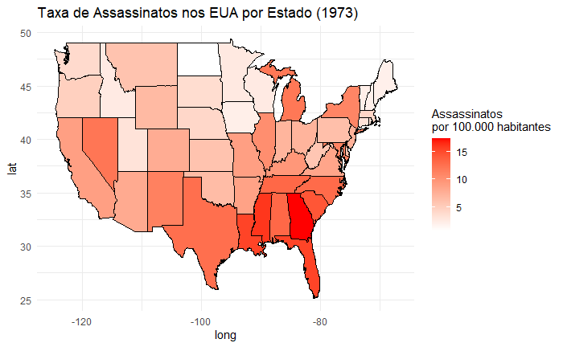

```r
ggplot(us_arrests_map, aes(x = long, y = lat, group = group, fill = Murder)) +
  geom_polygon(color = "black") +
  scale_fill_gradient(low = "white", high = "red") +
  labs(title = "Taxa de Assassinatos nos EUA por Estado (1973)",
       fill = "Assassinatos\npor 100.000 habitantes") +
  theme_minimal()
```

# Criando Mapas para Outras Variáveis

Agora, vamos criar mapas para outras variáveis, como `Assault` e `Rape`.

## Mapa para `Assault`

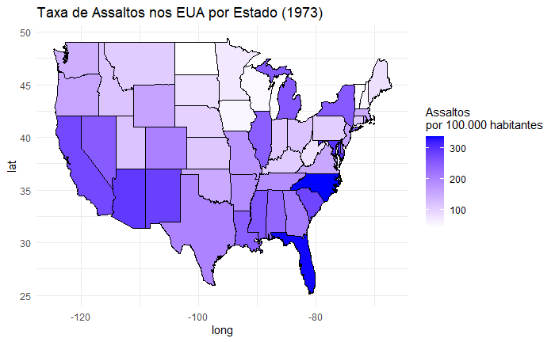

```r
ggplot(us_arrests_map, aes(x = long, y = lat, group = group, fill = Assault)) +
  geom_polygon(color = "black") +
  scale_fill_gradient(low = "white", high = "blue") +
  labs(title = "Taxa de Assaltos nos EUA por Estado (1973)",
       fill = "Assaltos\npor 100.000 habitantes") +
  theme_minimal()
```

## Mapa para `Rape`

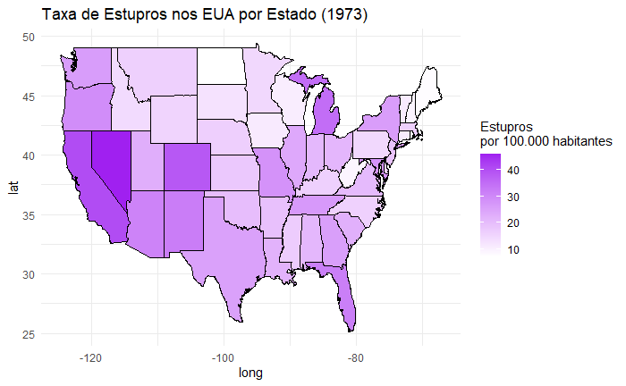

```r
ggplot(us_arrests_map, aes(x = long, y = lat, group = group, fill = Rape)) +
  geom_polygon(color = "black") +
  scale_fill_gradient(low = "white", high = "purple") +
  labs(title = "Taxa de Estupros nos EUA por Estado (1973)",
       fill = "Estupros\npor 100.000 habitantes") +
  theme_minimal()
```

# Salvando os Mapas

Finalmente, vamos aprender como salvar esses gráficos em diferentes formatos, como PDF e PNG.

## Salvando como PDF

```r
ggsave("mapa_assassinatos.pdf", width = 8, height = 6)
```

## Salvando como PNG

```r
ggsave("mapa_assassinatos.png", width = 8, height = 6, dpi = 300)
```

# Considerações Finais

Nesta aula, exploramos como utilizar dados geoespaciais e dados de crimes para criar mapas temáticos. Com isso, conseguimos visualizar padrões geográficos em variáveis quantitativas, facilitando a compreensão de dados complexos.